# Data Visualization

Using the seaborn, library we can compare variables in the anime dataframe to look for trends to see if we are able to trim data or make adjustments as needed to prevent bias.

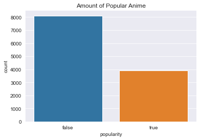

```python
plot = sns.countplot(x = anime_df['popularity'])
plot.set(title = 'Amount of Popular Anime')
plt.show()
```

We can see that there are a lot of anime that aren't considered popular (5000 or less people have watched it/given it a rating) which means that there is a lot of extra anime on the list that may or may not be significant

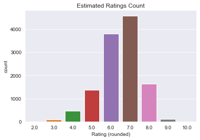

```python
plot = sns.countplot(x = anime_df['rating_rounded'])
plot.set(xlabel = 'Rating (rounded)', title = 'Estimated Ratings Count')
plt.show()
```

Most users are giving ratings around 6 or 7 which means that there are not many people leaving bad ratings, which is likely since they would not put the effort into giving it a bad rating if they didn't enjoy it.

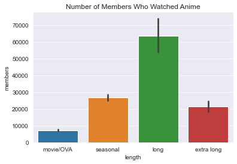

```python
plot = sns.barplot(data = anime_df, x = 'length', y = 'members')
plot.set(title = 'Number of Members Who Watched Anime')
plt.show()
```

There is a significant difference with the amount of members that watch long anime (25 episodes) compared to seasonal or extra long type anime (25+) which can be related to older anime which used to have 25 episodes

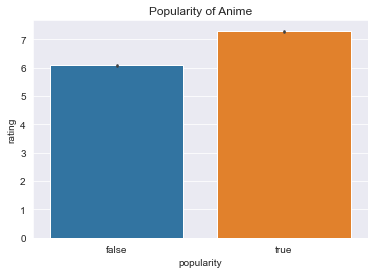

```python
plot = sns.barplot(data = anime_df, x = 'popularity', y = 'rating')
plot.set(title = 'Popularity of Anime')
plt.show()
```

The average rating of popular anime, which does not have a large difference which means that the smaller audiences enjoyed the anime that they watched

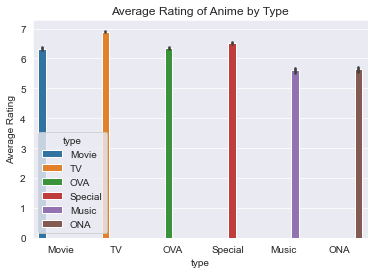

```python
plot = sns.barplot(x = anime_df['type'], y = anime_df['rating_rounded'], hue= anime_df['type'])
plot.set(ylabel = 'Average Rating', title = 'Average Rating of Anime by Type')
plt.show()
```

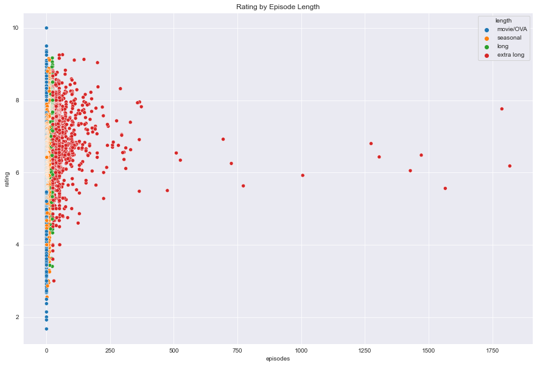

```python
plt.figure(figsize = (15, 10))
plot = sns.scatterplot(x = anime_df['episodes'], y = anime_df['rating'], hue = anime_df['length'])
plot.set(title = 'Rating by Episode Length')
plt.show()
```

The spread is the same as the bar plot in the beginning which means that there is not very much impact on the some variables to the rating

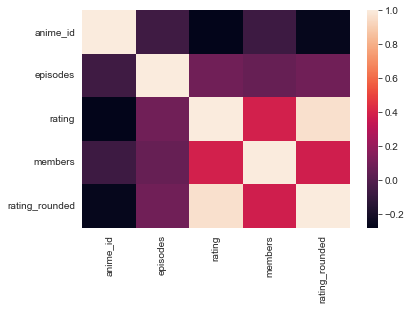

```python
sns.heatmap(data = anime_df.corr())
```

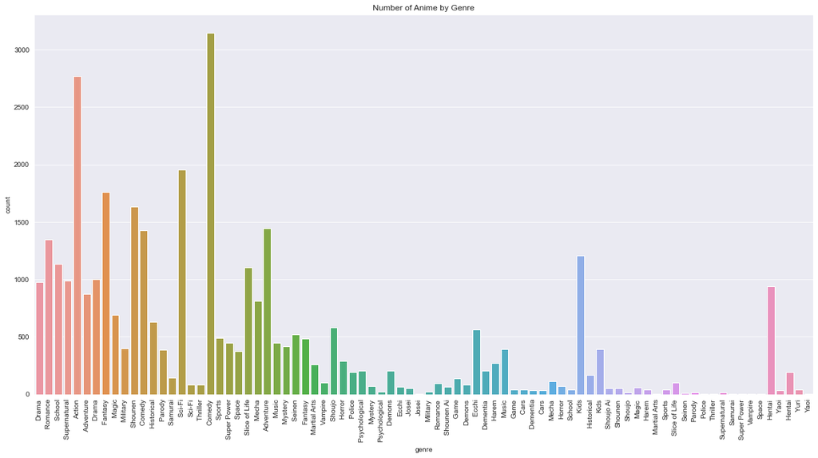

```python
genre_occur = pd.DataFrame(data = list(genre_counts.items()), columns = ['genre', 'count'])
genre_occur

figure(figsize = (20, 10))
plot = sns.barplot(data = genre_occur, x = 'genre', y = 'count')
plot.set(title = 'Number of Anime by Genre')
plot.set_xticklabels(genre_occur['genre'], rotation = 90)
plt.show()
```

```python
genre_occur['average_rating'] = 0
for key in genre_counts:
    parse = anime_df['genre'].apply(lambda x: key in x)
    temp_df = anime_df[parse]
    genre_occur.loc[genre_occur[genre_occur['genre'] == key].index, 'average_rating'] = weighted_average(temp_df, 'rating', 'members')

genre_occur
```

|  | genre | count | average_rating |
| --- | --- | --- | --- |
| 0 | Drama | 974 | 7.903136 |
| 1 | Romance | 1344 | 7.650901 |
| 2 | School | 1134 | 7.665066 |
| 3 | Supernatural | 987 | 7.826794 |
| 4 | Action | 2768 | 7.739501 |
| ... | ... | ... | ... |
| 77 | Hentai | 940 | 6.558099 |
| 78 | Yaoi | 36 | 6.462542 |
| 79 | Hentai | 193 | 6.584938 |
| 80 | Yuri | 41 | 6.486908 |
| 81 | Yaoi | 2 | 6.446115 |

82 rows × 3 columns

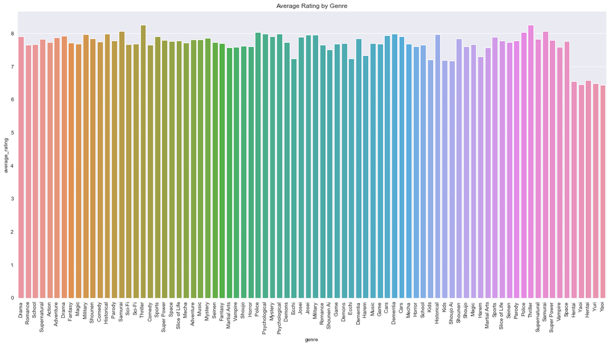

```python
figure(figsize = (20, 10))
plot = sns.barplot(data = genre_occur, x = 'genre', y = 'average_rating')
plot.set(title = 'Average Rating by Genre')
plot.set_xticklabels(genre_occur['genre'], rotation = 90)
plt.show()
```

```python
recommendation('91 Days', 1000)
```

```
--Recommendations based on 91 Days--
 PearsonR                                                     name  count     mean
 0.702516                                      Hoozuki no Reitetsu   1102 8.302178
 0.701268                               Mahou Shoujo Madoka★Magica   1337 7.691847
 0.696673                                                 Kamichu!   1213 7.183842
 0.677109                                                HeatGuy J   1250 6.883200
 0.672820 Detective Conan Movie 17: Private Eye in the Distant Sea   1259 8.062748
 0.653003                            Diamond no Ace: Second Season   1381 7.498190
 0.647051                                               Tokyo 2164   1375 7.215273
 0.643462                  Taka no Tsume 8: Yoshida-kun no X-Files   1321 7.570780
 0.643418                                               GetBackers   1043 8.237776
 0.631048             Sore Ike! Anpanman: Tsumiki Shiro no Himitsu   1467 7.689162
 0.625661                                               Texhnolyze   2272 7.576144
 0.624853                                               Happy Jozy   1913 7.723994
 0.620889                                       Grappler Baki (TV)   1877 6.807139
 0.615825                                       Hakuouki Sekkaroku   1094 8.064899
 0.613773                                               Rescue Me!   1295 7.840154
```

```python
recommendation('Tokyo Ghoul', 1000)
```

```
--Recommendations based on Tokyo Ghoul--
 PearsonR                                                                                   name  count     mean
 1.000000                                                                            Tokyo Ghoul   2245 7.650780
 0.787882                                                                         Azumanga Daioh   2406 7.724439
 0.782668                                                                    Yume-iro Pâtissière   2304 7.980035
 0.780600                                                                    Usagi Drop Specials   2558 7.823299
 0.697320                                                Saint Seiya: Meiou Hades Juuni Kyuu-hen   7603 8.040247
 0.624728                                                            Uchuu Shounen Soran (Movie)   1416 7.507062
 0.607536                                                           Kyoukai no Kanata: Shinonome   1198 7.041736
 0.579972                                                                               Bokurano   1560 7.476282
 0.572656                                   Saikin, Imouto no Yousu ga Chotto Okashiinda ga. OVA   1204 7.237542
 0.563708                                                                                 Orange   2395 6.903967
 0.556810                               Detective Conan Movie 17: Private Eye in the Distant Sea   1259 8.062748
 0.550335                                                                   Shinigami no Ballad.   2161 7.625174
 0.549712                                                               Rakudai Kishi no Cavalry   2393 7.210614
 0.547285                                                                        Boku wa Ou-sama   3781 7.838667
 0.546994 One Piece: Episode of Sabo - 3 Kyoudai no Kizuna Kiseki no Saikai to Uketsugareru Ishi   2728 7.043622
```

```python
recommendation('Konjiki no Gash Bell!!', 1000)
```

```
--Recommendations based on Konjiki no Gash Bell!!--
 PearsonR                                                                     name  count     mean
 0.942809                                                           Sakura no Ondo   1416 7.963983
 0.891056                                                               GetBackers   1043 8.237776
 0.821584                                                             Tokyo Ravens   1353 7.162602
 0.810093                                                        Arashi no Yoru ni   1018 7.154224
 0.800364                                      Qin Shiming Yue Zhi: Junlin Tianxia   2585 8.242166
 0.797940                                              Hiiro no Kakera Dai Ni Shou   1104 7.072464
 0.782308                                                         Robby to Kerobby   1766 6.776897
 0.760726                                    Peach Command Shin Momotarou Densetsu   3109 6.796076
 0.728578                                             Kyoukai no Kanata: Shinonome   1198 7.041736
 0.719301                                     Panty &amp; Stocking with Garterbelt   1663 7.267589
 0.704998 Slam Dunk: Hoero Basketman-damashii! Hanamichi to Rukawa no Atsuki Natsu   2556 7.178795
 0.677115                                                           Iketeru Futari   1342 7.163934
 0.675382                                      JoJo no Kimyou na Bouken: Adventure   4393 8.375825
 0.672493                                                          Nagi no Asukara   2595 7.990751
 0.670820                                                 Rakudai Kishi no Cavalry   2393 7.210614
```

```python
recommendation('Fullmetal Alchemist: Brotherhood', 1000)
```

```
--Recommendations based on Fullmetal Alchemist: Brotherhood--
 PearsonR                                                                         name  count     mean
 1.000000                                             Fullmetal Alchemist: Brotherhood  13449 8.869433
 0.561158                    Haikyuu!!: Karasuno Koukou VS Shiratorizawa Gakuen Koukou   5790 8.439724
 0.342475                                                                    Haikyuu!!   7485 8.305945
 0.329705                                                       Ouran Koukou Host Club  13679 8.807077
 0.322020                      Code Geass: Boukoku no Akito 2 - Hikisakareshi Yokuryuu   1730 8.282081
 0.315074                           Detective Conan Movie 14: The Lost Ship in the Sky  11118 8.107483
 0.314993                                                               Bakemonogatari   1250 7.901600
 0.311537                                                       Hunter x Hunter (2011)   9385 8.419393
 0.309657                                                      Ping Pong The Animation   8296 8.145251
 0.306819                                             Layton Kyouju to Eien no Utahime   1135 8.186784
 0.306501                                                                   Soul Eater   1320 8.331818
 0.297115                                         Mahou Shoujo Lyrical Nanoha A&#039;s   3006 8.018297
 0.296562                                     Mobile Suit Gundam: Iron-Blooded Orphans   6664 8.634154
 0.292194                                           Nogizaka Haruka no Himitsu: Finale   5756 8.200313
 0.290768 Sengoku Basara: Setonai no Gekitotsu! Hi wo Fuku Umi no Daiyousai - Fugaku!!   9710 8.660659
```

```python
recommendation('Clannad', 1000)
```

```
--Recommendations based on Clannad--
 PearsonR                                                                                   name  count     mean
 1.000000                                                                                Clannad  11696 8.169716
 0.711571                                                         Hidamari Sketch x 365 Specials  14211 8.314967
 0.573559                                                                      Minami-ke Tadaima   1112 7.366007
 0.566722                                                          Zoku Sayonara Zetsubou Sensei   1363 7.090242
 0.560871                                                                             Texhnolyze   2272 7.576144
 0.558972                                                                       Momo e no Tegami   2790 6.989606
 0.549859                                                           Kyoukai no Kanata: Shinonome   1198 7.041736
 0.546877                                                                     Nurarihyon no Mago   2562 6.953552
 0.539117                                                      Tenchi Muyou! Ryououki 2nd Season   2575 7.770874
 0.537204                                                                      Shakugan no Shana   2310 7.736364
 0.536610 One Piece: Episode of Sabo - 3 Kyoudai no Kizuna Kiseki no Saikai to Uketsugareru Ishi   2728 7.043622
 0.531065                                                                             Over Drive   2789 7.277160
 0.530699                                                               Rakudai Kishi no Cavalry   2393 7.210614
 0.521859                                                                       Ranma ½ Specials   3051 7.696821
 0.520194                                                                 Rozen Maiden: Träumend   2324 7.400172
```